# Predicting Loan Eligibility

```python
cols = df_categ.columns.tolist()
for col in cols:
    print(f'{col}:\n {df_categ[col].value_counts()}\n')
```

```
Gender:
 Male      489
Female    112
Name: Gender, dtype: int64

Married:
 Yes    398
No     213
Name: Married, dtype: int64

Dependents:
 0     345
1     102
2     101
3+     51
Name: Dependents, dtype: int64

Education:
 Graduate        480
Not Graduate    134
Name: Education, dtype: int64

Self_Employed:
 No     500
Yes     82
Name: Self_Employed, dtype: int64

LoanAmount:
 120.0    20
110.0    17
100.0    15
160.0    12
187.0    12
         ..
240.0     1
214.0     1
59.0      1
166.0     1
253.0     1
Name: LoanAmount, Length: 203, dtype: int64
```

[output cut: 61 more lines]

```
8.430109    4
7.824046    4
9.028099    3
           ..
8.501673    1
8.536996    1
9.305651    1
8.737453    1
8.933664    1
Name: log_combined_incomes, Length: 554, dtype: int64

second_applicant:
 1.0    341
0.0    273
Name: second_applicant, dtype: int64
```

```python
def linechart_avg_loan_by_categ_ratio(df):
    df_in = df.drop(columns=['Loan_Status'])
    cat_cols = list(df_in.dtypes[df_in.dtypes == 'object'].index)
    loan_status = df['Loan_Status']
    for col in cat_cols:
        # Calculate col proportions as percentage
        col_perc = pd.DataFrame(round(df[col].value_counts(normalize=True)*100, 0)).reset_index()
        col_perc.columns = [col, f'%_{col}']
        df = pd.merge(left=df, right=col_perc, how='inner', on=[col])

        piv = round(pd.pivot_table(
                df
            , values = 'LoanAmount'
            , index = [col, f'%_{col}']
            , columns =  loan_status
            , aggfunc = 'mean'
        ), 2) # Round to 2 dec points

        title=f'Mean Loan $ by {col} as % Loan Status'
        piv.plot.line(
            title= title
            , color= {'N': 'red', 'Y': 'green'}
            , figsize= (14, 3)
        )
        plt.savefig(f'../images/linechart_avg_loan_by_{col}_ratio.png')

        print(f'{title}:\n {piv}\n')
```

```
Mean Loan $ by Gender as % Loan Status:
 Loan_Status           N       Y
Gender %_Gender
Female 19.0      120.68  129.92
Male   81.0      150.92  148.51

Mean Loan $ by Married as % Loan Status:
 Loan_Status             N       Y
Married %_Married
No      35.0       129.91  127.68
Yes     65.0       154.94  153.51

Mean Loan $ by Dependents as % Loan Status:
 Loan_Status                   N       Y
Dependents %_Dependents
0          58.0          146.50  131.47
1          17.0          171.70  151.52
2          17.0          165.76  142.98
3+         8.0           130.69  190.70

Mean Loan $ by Education as % Loan Status:
 Loan_Status                    N       Y
Education    %_Education
Graduate     78.0         151.39  153.57
Not Graduate 22.0         122.07  116.01

Mean Loan $ by Self_Employed as % Loan Status:
 Loan_Status                         N       Y
Self_Employed %_Self_Employed
No            86.0             142.10  139.88
Yes           14.0             175.04  171.04

Mean Loan $ by Property_Area as % Loan Status:
 Loan_Status                         N       Y
Property_Area %_Property_Area
Rural         29.0             134.14  160.52
Semiurban     38.0             150.23  144.25
Urban         32.0             142.69  132.56
```

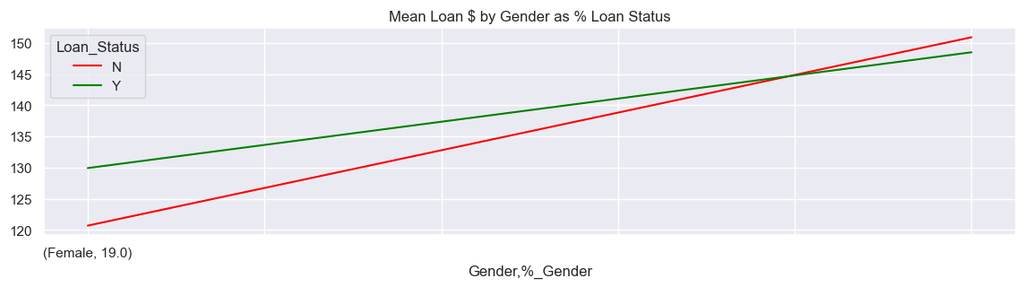

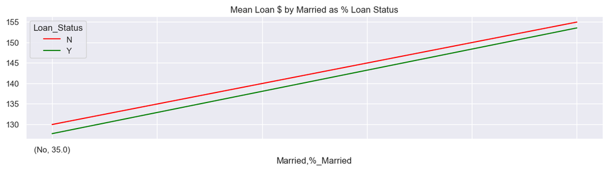

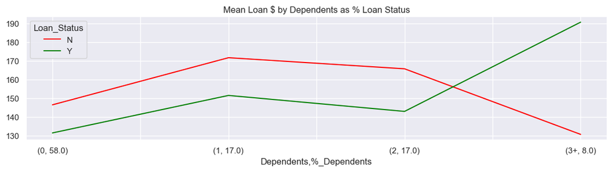

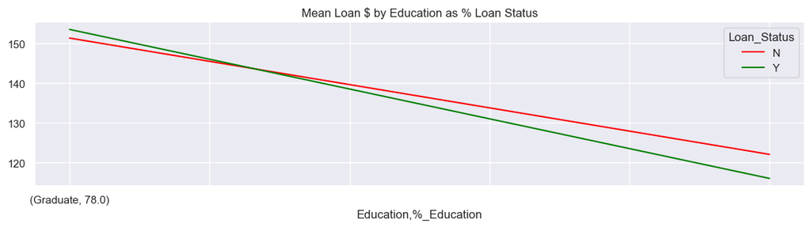

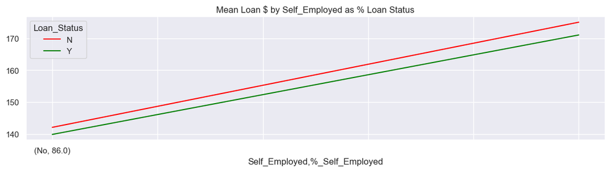

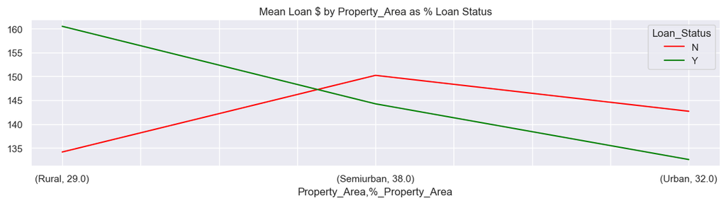

```python
linechart_avg_loan_by_categ_ratio(df)
```

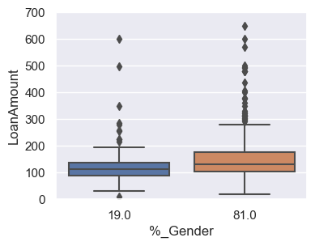

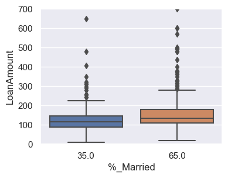

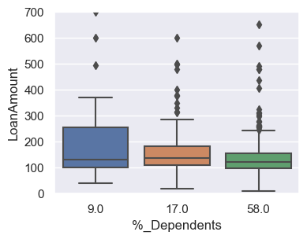

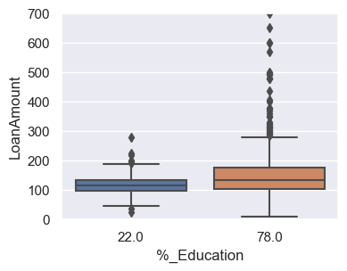

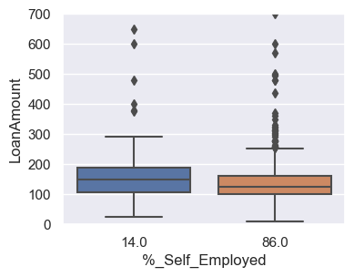

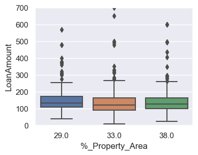

```python
def boxplot_avg_loan_by_categ_ratio(df):
    df_in = df.drop(columns=['Loan_Status'])
    cat_cols = list(df_in.dtypes[df_in.dtypes == 'object'].index)
    loan_status = df['Loan_Status']
    for col in cat_cols:

        # Calculate col proportions as percentage
        col_perc = pd.DataFrame(round(df[col].value_counts(normalize=True)*100, 0)).reset_index()
        col_perc.columns = [col, f'%_{col}']
        df_per = pd.merge(left=df, right=col_perc, how='inner', on=[col])
        x_var = f'%_{col}'

        # Self_Employed
        data = df_per[['LoanAmount', x_var]]
        f, ax = plt.subplots(figsize=(4, 3))
        fig = sns.boxplot(x=x_var, y="LoanAmount", data=data)
        fig.axis(ymin=-0, ymax=700)

        plt.savefig(f'../images/boxplot_avg_loan_by_{col}_ratio.png')


boxplot_avg_loan_by_categ_ratio(df)
```

```python
df[categoric].head()
```

|  | Gender | Married | Dependents | Education | Self_Employed | Property_Area | Loan_Status |
| --- | --- | --- | --- | --- | --- | --- | --- |
| 0 | Male | No | 0 | Graduate | No | Urban | Y |
| 1 | Male | Yes | 1 | Graduate | No | Rural | N |
| 2 | Male | Yes | 0 | Graduate | Yes | Urban | Y |
| 3 | Male | Yes | 0 | Not Graduate | No | Urban | Y |
| 4 | Male | No | 0 | Graduate | No | Urban | Y |

TOP OF PAGE/TOC

## PART 3: Data Cleaning

This step typically involves imputing missing values and treating outliers.

### IMPUTING MISSING VALUES:

Missing values may not always be NaNs. For instance, the `Loan_Amount_Term` might be 0, which does not make sense.

Impute missing values for all columns. Use the values which you find most meaningful (mean, mode, median, zero.... maybe different mean values for different groups)

```python
nulls_remaining = null_proportions(df, True)
```

```
Shape of data: (614, 14)
Nulls remaining:
```

|  | variable | null_cnt | null_% | dtype |
| --- | --- | --- | --- | --- |
| 7 | Credit_History | 50 | 8.1 | float64 |
| 4 | Self_Employed | 32 | 5.2 | object |
| 5 | LoanAmount | 22 | 3.6 | float64 |
| 11 | log_LoanAmount | 22 | 3.6 | float64 |
| 2 | Dependents | 15 | 2.4 | object |
| 6 | Loan_Amount_Term | 14 | 2.3 | float64 |
| 0 | Gender | 13 | 2.1 | object |
| 1 | Married | 3 | 0.5 | object |

##### VARIABLE: Credit_History

Credit_History is about 8% null, and should also be converted to integer data type as it's value is representative of the boolean regarding a presence or an absence of a Credit History.

Before imputing the null values, observing the null Credit History values for any observable reason *not* to assume the nulls could simply be defaulted to 0, since it's binary value really only describes a potentially additive quality of the individual having a Credit History.

Differences between null, positive, and negative Credit History:

```python
# Credit_History Descriptive Stats:
Null = (df[df['Credit_History'].isna()])
No = (df[df['Credit_History']==0.0])
Yes = (df[df['Credit_History']==1.0])
```

Do more Credit_History nulls correlate with increased null values elsewhere?

```python
# Credit_History Null proportions:
print('\nCredit_History: Null')
x = null_proportions(Null, True)
print('\nCredit_History: No')
x = null_proportions(No, True)
print('\nCredit_History: Yes')
x = null_proportions(Yes, True)
```

```
Credit_History: Null
Shape of data: (50, 14)
Nulls remaining:
```

|  | variable | null_cnt | null_% | dtype |
| --- | --- | --- | --- | --- |
| 7 | Credit_History | 50 | 100.0 | float64 |
| 4 | Self_Employed | 6 | 12.0 | object |
| 0 | Gender | 1 | 2.0 | object |
| 5 | LoanAmount | 1 | 2.0 | float64 |
| 11 | log_LoanAmount | 1 | 2.0 | float64 |

```
Credit_History: No
Shape of data: (89, 14)
Nulls remaining:
```

|  | variable | null_cnt | null_% | dtype |
| --- | --- | --- | --- | --- |
| 6 | Loan_Amount_Term | 6 | 6.7 | float64 |
| 2 | Dependents | 5 | 5.6 | object |
| 5 | LoanAmount | 4 | 4.5 | float64 |
| 11 | log_LoanAmount | 4 | 4.5 | float64 |
| 0 | Gender | 3 | 3.4 | object |
| 4 | Self_Employed | 1 | 1.1 | object |

```
Credit_History: Yes
Shape of data: (475, 14)
Nulls remaining:
```

|  | variable | null_cnt | null_% | dtype |
| --- | --- | --- | --- | --- |
| 4 | Self_Employed | 25 | 5.3 | object |
| 5 | LoanAmount | 17 | 3.6 | float64 |
| 11 | log_LoanAmount | 17 | 3.6 | float64 |
| 2 | Dependents | 10 | 2.1 | object |
| 0 | Gender | 9 | 1.9 | object |
| 6 | Loan_Amount_Term | 8 | 1.7 | float64 |
| 1 | Married | 3 | 0.6 | object |

Do the null Credit_History values have significantly different stats distributions to the known Credit_History values?

```python
# Credit_History Descriptive Stats:
print(f'\nCredit_History: Null \nShape of Null: {Null.shape}')
display(descriptive_statistics(Null))
print(f'\nCredit_History: No \nShape of No: {No.shape}')
display(descriptive_statistics(No))
print(f'\nCredit_History: Yes \nShape of Yes: {Yes.shape}')
display(descriptive_statistics(Yes))
```

```
Credit_History: Null
Shape of Null: (50, 14)
```

|  | variable | sum | count | mean | std | min | median | max |
| --- | --- | --- | --- | --- | --- | --- | --- | --- |
| 0 | LoanAmount | 7893.000000 | 49 | 161.1 | 107.6 | 58.000000 | 130.000000 | 650.000000 |
| 1 | Loan_Amount_Term | 17016.000000 | 50 | 340.3 | 71.4 | 12.000000 | 360.000000 | 480.000000 |
| 2 | Credit_History | 0.000000 | 0 | NaN | NaN | NaN | NaN | NaN |
| 3 | combined_incomes | 366926.000000 | 50 | 7338.5 | 6678.5 | 1880.000000 | 5873.000000 | 42083.000000 |
| 4 | log_LoanAmount | 241.865491 | 49 | 4.9 | 0.5 | 4.060443 | 4.867534 | 6.476972 |
| 5 | log_combined_incomes | 434.798338 | 50 | 8.7 | 0.6 | 7.539027 | 8.677887 | 10.647399 |
| 6 | second_applicant | 31.000000 | 50 | 0.6 | 0.5 | 0.000000 | 1.000000 | 1.000000 |

```
Credit_History: No
Shape of No: (89, 14)
```

|  | variable | sum | count | mean | std | min | median | max |
| --- | --- | --- | --- | --- | --- | --- | --- | --- |
| 0 | LoanAmount | 12471.000000 | 85 | 146.7 | 85.2 | 45.000000 | 125.000000 | 600.000000 |
| 1 | Loan_Amount_Term | 28380.000000 | 83 | 341.9 | 66.7 | 180.000000 | 360.000000 | 480.000000 |
| 2 | Credit_History | 0.000000 | 89 | 0.0 | 0.0 | 0.000000 | 0.000000 | 0.000000 |
| 3 | combined_incomes | 642724.000000 | 89 | 7221.6 | 9227.6 | 1830.000000 | 5230.000000 | 81000.000000 |
| 4 | log_LoanAmount | 414.874036 | 85 | 4.9 | 0.4 | 3.806662 | 4.828314 | 6.396930 |
| 5 | log_combined_incomes | 769.130063 | 89 | 8.6 | 0.6 | 7.512071 | 8.562167 | 11.302204 |
| 6 | second_applicant | 48.000000 | 89 | 0.5 | 0.5 | 0.000000 | 1.000000 | 1.000000 |

```
Credit_History: Yes
Shape of Yes: (475, 14)
```

|  | variable | sum | count | mean | std | min | median | max |
| --- | --- | --- | --- | --- | --- | --- | --- | --- |
| 0 | LoanAmount | 6.631200e+04 | 458 | 144.8 | 83.1 | 9.000000 | 128.000000 | 700.000000 |
| 1 | Loan_Amount_Term | 1.598040e+05 | 467 | 342.2 | 64.3 | 36.000000 | 360.000000 | 480.000000 |
| 2 | Credit_History | 4.750000e+02 | 475 | 1.0 | 0.0 | 1.000000 | 1.000000 | 1.000000 |
| 3 | combined_incomes | 3.303519e+06 | 475 | 6954.8 | 5788.4 | 1442.000000 | 5416.000000 | 63337.000000 |
| 4 | log_LoanAmount | 2.218867e+03 | 458 | 4.8 | 0.5 | 2.197225 | 4.852030 | 6.551080 |
| 5 | log_combined_incomes | 4.119092e+03 | 475 | 8.7 | 0.5 | 7.273786 | 8.597113 | 11.056225 |
| 6 | second_applicant | 2.620000e+02 | 475 | 0.6 | 0.5 | 0.000000 | 1.000000 | 1.000000 |

At the moment I don't see an obvious reason why the credit_history nulls couldn't be imputed to 0 values:

```python
df['Credit_History'] = df['Credit_History'].fillna(0)
df['Credit_History'].astype('int')
nulls_remaining = null_proportions(df, True)
df['Credit_History'].value_counts()
```

```
Shape of data: (614, 14)
Nulls remaining:
```

|  | variable | null_cnt | null_% | dtype |
| --- | --- | --- | --- | --- |
| 4 | Self_Employed | 32 | 5.2 | object |
| 5 | LoanAmount | 22 | 3.6 | float64 |
| 11 | log_LoanAmount | 22 | 3.6 | float64 |
| 2 | Dependents | 15 | 2.4 | object |
| 6 | Loan_Amount_Term | 14 | 2.3 | float64 |
| 0 | Gender | 13 | 2.1 | object |
| 1 | Married | 3 | 0.5 | object |

```
1.0    475
0.0    139
Name: Credit_History, dtype: int64
```

```python
df.head()
```

|  | Gender | Married | Dependents | Education | Self_Employed | LoanAmount | Loan_Amount_Term | Credit_History | Property_Area | Loan_Status | combined_incomes | log_LoanAmount | log_combined_incomes | second_applicant |
| --- | --- | --- | --- | --- | --- | --- | --- | --- | --- | --- | --- | --- | --- | --- |
| 0 | Male | No | 0 | Graduate | No | NaN | 360.0 | 1.0 | Urban | Y | 5849.0 | NaN | 8.674026 | 0.0 |
| 1 | Male | Yes | 1 | Graduate | No | 128.0 | 360.0 | 1.0 | Rural | N | 6091.0 | 4.852030 | 8.714568 | 1.0 |
| 2 | Male | Yes | 0 | Graduate | Yes | 66.0 | 360.0 | 1.0 | Urban | Y | 3000.0 | 4.189655 | 8.006368 | 0.0 |
| 3 | Male | Yes | 0 | Not Graduate | No | 120.0 | 360.0 | 1.0 | Urban | Y | 4941.0 | 4.787492 | 8.505323 | 1.0 |
| 4 | Male | No | 0 | Graduate | No | 141.0 | 360.0 | 1.0 | Urban | Y | 6000.0 | 4.948760 | 8.699515 | 0.0 |

##### VARIABLE: LoanAmount

```python
loan_amount_df = df[df['LoanAmount'].isna()].copy()
print(loan_amount_df.shape)
loan_amount_df.count()
```

```
(22, 14)
```

```
Gender                  22
Married                 21
Dependents              20
Education               22
Self_Employed           21
LoanAmount               0
Loan_Amount_Term        22
Credit_History          22
Property_Area           22
Loan_Status             22
combined_incomes        22
log_LoanAmount           0
log_combined_incomes    22
second_applicant        22
dtype: int64
```

```python
cols = loan_amount_df.columns
dict_loan_na = {}
for var in cols:
    if loan_amount_df[var].nunique() < 12:
      var_dict = loan_amount_df[var].value_counts().to_dict()
      dict_loan_na[var] = var_dict

loan_na_df = pd.DataFrame.from_dict(dict_loan_na, orient="index", ).stack().to_frame()
loan_na_df
```

|  |  | 0 |
| --- | --- | --- |
| Gender | Male | 19.0 |
|  | Female | 3.0 |
| Married | Yes | 14.0 |
|  | No | 7.0 |
| Self_Employed | Yes | 3.0 |
|  | No | 18.0 |
| Dependents | 0 | 11.0 |
|  | 1 | 4.0 |
|  | 2 | 3.0 |
|  | 3+ | 2.0 |
| Education | Graduate | 15.0 |
|  | Not Graduate | 7.0 |
| Loan_Amount_Term | 360.0 | 19.0 |
|  | 180.0 | 2.0 |
|  | 240.0 | 1.0 |
| Credit_History | 1.0 | 17.0 |
|  | 0.0 | 5.0 |
| second_applicant | 1.0 | 10.0 |
|  | 0.0 | 12.0 |
| Property_Area | Urban | 11.0 |
|  | Rural | 6.0 |
|  | Semiurban | 5.0 |
| Loan_Status | Y | 11.0 |
|  | N | 11.0 |

I don't see an obvious specific trend, and there are only 22 values, which are evenly split between loan status yes and no. Likely okay to impute the missing 22 values with the mean.

```python
# Impute missing LoanAmount values to the mean:
df['LoanAmount'] = df['LoanAmount'].fillna(df['LoanAmount'].mean())
df['LoanAmount'].astype('float')

# Re-calculate the log transforms:
df["log_LoanAmount"] = df["LoanAmount"].apply(np.log)

nulls_remaining = null_proportions(df, True)
```

```
Shape of data: (614, 14)
Nulls remaining:
```

|  | variable | null_cnt | null_% | dtype |
| --- | --- | --- | --- | --- |
| 4 | Self_Employed | 32 | 5.2 | object |
| 2 | Dependents | 15 | 2.4 | object |
| 6 | Loan_Amount_Term | 14 | 2.3 | float64 |
| 0 | Gender | 13 | 2.1 | object |
| 1 | Married | 3 | 0.5 | object |

##### VARIABLE: Loan_Amount_Term

```python
Loan_Amount_Term = df[df['Loan_Amount_Term'].isna()].copy()
print(Loan_Amount_Term.shape)
Loan_Amount_Term.count()
```

```
(14, 14)
```

```
Gender                  14
Married                 14
Dependents              13
Education               14
Self_Employed           13
LoanAmount              14
Loan_Amount_Term         0
Credit_History          14
Property_Area           14
Loan_Status             14
combined_incomes        14
log_LoanAmount          14
log_combined_incomes    14
second_applicant        14
dtype: int64
```

```python
cols = Loan_Amount_Term.columns
Loan_Amount_Term_na = {}
for var in cols:
    if Loan_Amount_Term[var].nunique() < 10:
      var_dict = Loan_Amount_Term[var].value_counts().to_dict()
      Loan_Amount_Term_na[var] = var_dict

Loan_Amount_Term_df = pd.DataFrame.from_dict(Loan_Amount_Term_na, orient="index", ).stack().to_frame()
Loan_Amount_Term_df
```

|  |  | 0 |
| --- | --- | --- |
| Gender | Male | 11.0 |
|  | Female | 3.0 |
| Married | Yes | 9.0 |
|  | No | 5.0 |
| Self_Employed | Yes | 2.0 |
|  | No | 11.0 |
| Dependents | 0 | 11.0 |
|  | 3+ | 1.0 |
|  | 1 | 1.0 |
| Education | Graduate | 8.0 |
|  | Not Graduate | 6.0 |
| Credit_History | 1.0 | 8.0 |
|  | 0.0 | 6.0 |
| second_applicant | 1.0 | 9.0 |
|  | 0.0 | 5.0 |
| Property_Area | Urban | 7.0 |
|  | Rural | 4.0 |
|  | Semiurban | 3.0 |
| Loan_Status | Y | 8.0 |
|  | N | 6.0 |

again the nulls in the loan amount term appear to be as well distributed as 14 records can be. The records do not match the missing records with the remaining missing values, so I'll refrain from dropping these, and repeat imputation with it's mean.

```python
# Impute missing Loan_Amount_Term values to the mean:
df['Loan_Amount_Term'] = df['Loan_Amount_Term'].fillna(df['Loan_Amount_Term'].mean())
df['Loan_Amount_Term'].astype('float')

# Assess remaining null values
nulls_remaining = null_proportions(df, True)
```

```
Shape of data: (614, 14)
Nulls remaining:
```

|  | variable | null_cnt | null_% | dtype |
| --- | --- | --- | --- | --- |
| 4 | Self_Employed | 32 | 5.2 | object |
| 2 | Dependents | 15 | 2.4 | object |
| 0 | Gender | 13 | 2.1 | object |
| 1 | Married | 3 | 0.5 | object |

```python
nulls_remaining = null_proportions(df, True)
```

```
Shape of data: (614, 14)
Nulls remaining:
```

|  | variable | null_cnt | null_% | dtype |
| --- | --- | --- | --- | --- |
| 4 | Self_Employed | 32 | 5.2 | object |
| 2 | Dependents | 15 | 2.4 | object |
| 0 | Gender | 13 | 2.1 | object |
| 1 | Married | 3 | 0.5 | object |

##### VARIABLE: Self_Employed

```python
Self_Employed = df[df['Self_Employed'].isna()].copy()
print(Self_Employed.shape)
Self_Employed.count()
```

```
(32, 14)
```

```
Gender                  32
Married                 32
Dependents              32
Education               32
Self_Employed            0
LoanAmount              32
Loan_Amount_Term        32
Credit_History          32
Property_Area           32
Loan_Status             32
combined_incomes        32
log_LoanAmount          32
log_combined_incomes    32
second_applicant        32
dtype: int64
```

```python
display(df['Self_Employed'].value_counts())
```

```
No     500
Yes     82
Name: Self_Employed, dtype: int64
```

Nevermind. Only 14% of the total values are 'Yes', I will impute to 'No'

```python
# Impute missing Self_Employed values to the mean:
df['Self_Employed'] = df['Self_Employed'].fillna('No')

# Assess remaining null values
nulls_remaining = null_proportions(df, True)
```

```
Shape of data: (614, 14)
Nulls remaining:
```

|  | variable | null_cnt | null_% | dtype |
| --- | --- | --- | --- | --- |
| 2 | Dependents | 15 | 2.4 | object |
| 0 | Gender | 13 | 2.1 | object |
| 1 | Married | 3 | 0.5 | object |

##### VARIABLE: Gender

```python
display(df['Gender'].value_counts())

Gender = df[df['Gender'].isna()].copy()
print(Gender.shape)
Gender.count()
```

```
Male      489
Female    112
Name: Gender, dtype: int64
```

```
(13, 14)
```

```
Gender                   0
Married                 13
Dependents              13
Education               13
Self_Employed           13
LoanAmount              13
Loan_Amount_Term        13
Credit_History          13
Property_Area           13
Loan_Status             13
combined_incomes        13
log_LoanAmount          13
log_combined_incomes    13
second_applicant        13
dtype: int64
```

Maybe these are not missing values. I will impute these to 0 so they'll remain as a third "unspecified" Gender when one-hot-encoding.

```python
# Impute missing Gender values to the mean:
df['Gender'] = df['Gender'].fillna(0)

# Assess remaining null values
nulls_remaining = null_proportions(df, True)
```

```
Shape of data: (614, 14)
Nulls remaining:
```

|  | variable | null_cnt | null_% | dtype |
| --- | --- | --- | --- | --- |
| 2 | Dependents | 15 | 2.4 | object |
| 1 | Married | 3 | 0.5 | object |

##### VARIABLE: Married

```python
Married = df[df['Married'].isna()].copy()
print(Married.shape)
Married.count()
```

```
(3, 14)
```

```
Gender                  3
Married                 0
Dependents              0
Education               3
Self_Employed           3
LoanAmount              3
Loan_Amount_Term        3
Credit_History          3
Property_Area           3
Loan_Status             3
combined_incomes        3
log_LoanAmount          3
log_combined_incomes    3
second_applicant        3
dtype: int64
```

meh. only 3.

```python
df.dropna(subset=['Married'], inplace=True)
nulls_remaining = null_proportions(df, True)
```

```
Shape of data: (611, 14)
Nulls remaining:
```

|  | variable | null_cnt | null_% | dtype |
| --- | --- | --- | --- | --- |
| 2 | Dependents | 12 | 2.0 | object |

##### VARIABLE: Dependents

```python
Dependents = df[df['Dependents'].isna()].copy()
print(Dependents.shape)
Dependents.count()
```

```
(12, 14)
```

```
Gender                  12
Married                 12
Dependents               0
Education               12
Self_Employed           12
LoanAmount              12
Loan_Amount_Term        12
Credit_History          12
Property_Area           12
Loan_Status             12
combined_incomes        12
log_LoanAmount          12
log_combined_incomes    12
second_applicant        12
dtype: int64
```

```python
display(df['Dependents'].value_counts())
```

```
0     345
1     102
2     101
3+     51
Name: Dependents, dtype: int64
```

Mwaa hAA!! Also to 0!

```python
df['Dependents'] = df['Dependents'].fillna('0')
nulls_remaining = null_proportions(df, True)
```

```
Shape of data: (611, 14)
Nulls remaining:
```

|  | variable | null_cnt | null_% | dtype |
| --- | --- | --- | --- | --- |

TOP OF PAGE/TOC

### EXTREME VALUES:

Try a log transformation to get rid of the extreme values in `LoanAmount`. Plot the histogram before and after the transformation

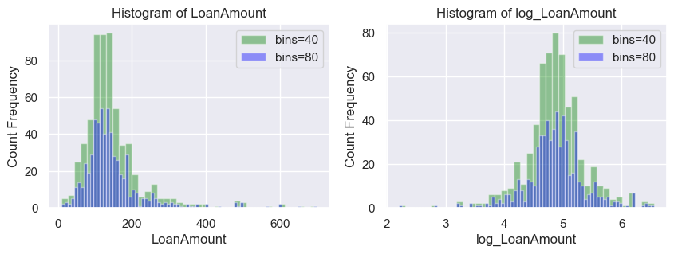

```
None
```

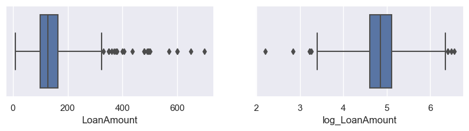

```
None
```

```python
# Way ahead of you ;)
print(hist_compare(df, 'LoanAmount', 'log_LoanAmount'))
print(boxplot_compare2_x(df, 'LoanAmount', 'log_LoanAmount'))
```

```python
log_LoanAmount = df['log_LoanAmount']

# Define the quantiles of the log_LoanAmount distribution:
Q1 = log_LoanAmount.quantile(0.25)
Q3 = log_LoanAmount.quantile(0.75)
IQR = Q3 - Q1

# Define the outlier thresholds using the 2.5 std of the whiskers in the box plots,
min_threshold = (Q1 - 2.5 * IQR)
max_threshold = (Q3 + 2.5 * IQR)
```

```python
df_clean = df[~((log_LoanAmount < min_threshold)|(log_LoanAmount > max_threshold))]
print(f'df.shape: {df.shape}')
print(f'df_clean.shape: {df_clean.shape}')
```

```
df.shape: (611, 14)
df_clean.shape: (602, 14)
```

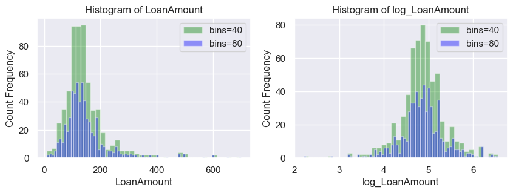

```
BEFORE:
 None
```

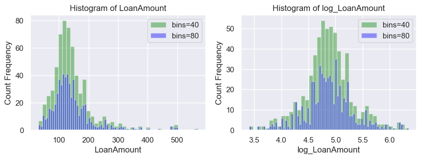

```
AFTER: 9 outliers dropped at threshold > 2.5 IQR
 None
```

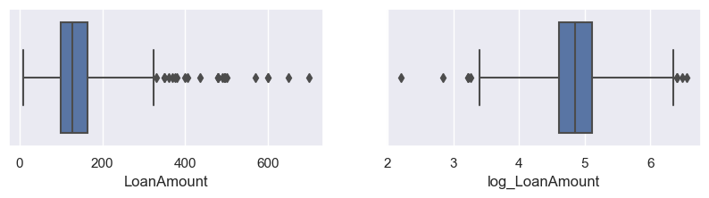

```
BEFORE:
 None
```

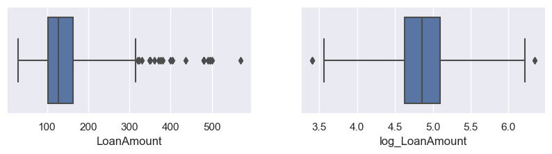

```
AFTER: 9 outliers dropped at threshold > 2.5 IQR
 None
```

```python
print(f"BEFORE:\n {hist_compare(df, 'LoanAmount', 'log_LoanAmount')}")
print(f"AFTER: 9 outliers dropped at threshold > 2.5 IQR\n {hist_compare(df_clean, 'LoanAmount', 'log_LoanAmount')}")

print(f"BEFORE:\n {boxplot_compare2_x(df, 'LoanAmount', 'log_LoanAmount')}")
print(f"AFTER: 9 outliers dropped at threshold > 2.5 IQR\n {boxplot_compare2_x(df_clean, 'LoanAmount', 'log_LoanAmount')}")
```

```python
# Will keep the changes:
df = df_clean.copy()
```

Combine both incomes as total income and take a log transformation of the same.

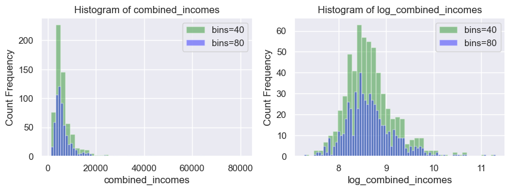

```
None
```

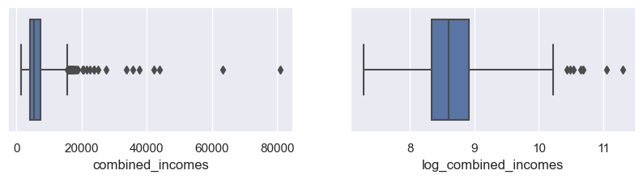

```
None
```

```python
# Are you kidding me!? ...
print(hist_compare(df, 'combined_incomes', 'log_combined_incomes'))
print(boxplot_compare2_x(df, 'combined_incomes', 'log_combined_incomes'))
```

```python
log_combined_incomes = df['log_combined_incomes']

# Define the quantiles of the log_combined_incomes distribution:
Q1 = log_combined_incomes.quantile(0.25)
Q3 = log_combined_incomes.quantile(0.75)
IQR = Q3 - Q1

# Define the outlier thresholds using the 2.5 std of the whiskers in the box plots,
min_threshold = (Q1 - 2.5 * IQR)
max_threshold = (Q3 + 2.5 * IQR)

df_clean = df[~((log_combined_incomes < min_threshold)|(log_combined_incomes > max_threshold))]
print(f'df.shape: {df.shape}')
print(f'df_clean.shape: {df_clean.shape}')
```

```
df.shape: (602, 14)
df_clean.shape: (595, 14)
```

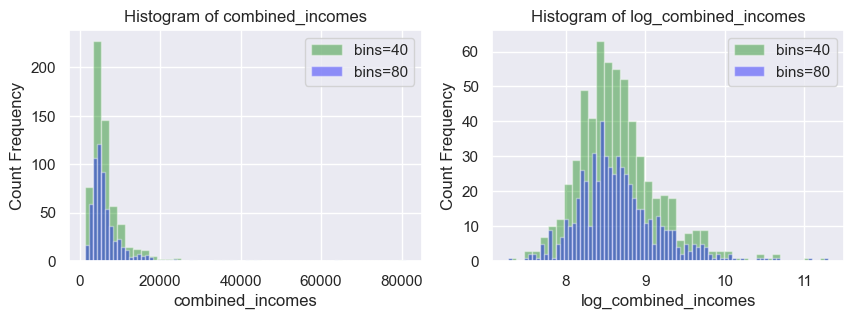

```
BEFORE:
 None
```

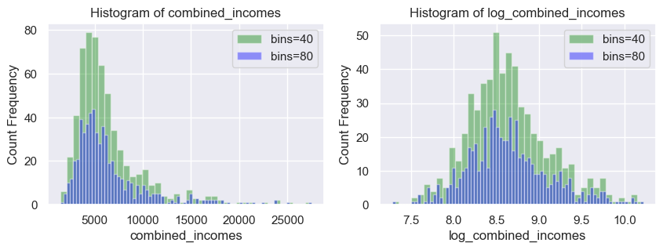

```
AFTER: 7 outliers dropped at threshold > 2.5 IQR
 None
```

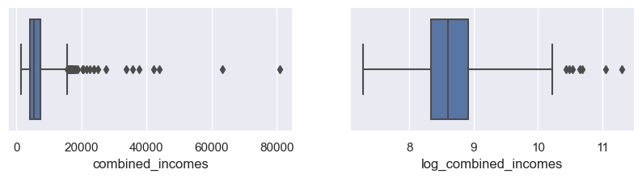

```
BEFORE:
 None
```

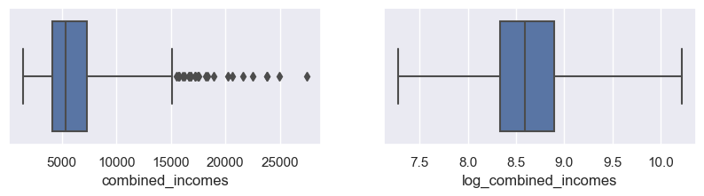

```
AFTER: 7 outliers dropped at threshold > 2.5 IQR
 None
```

```python
print(f"BEFORE:\n {hist_compare(df, 'combined_incomes', 'log_combined_incomes')}")
print(f"AFTER: 7 outliers dropped at threshold > 2.5 IQR\n {hist_compare(df_clean, 'combined_incomes', 'log_combined_incomes')}")

print(f"BEFORE:\n {boxplot_compare2_x(df, 'combined_incomes', 'log_combined_incomes')}")
print(f"AFTER: 7 outliers dropped at threshold > 2.5 IQR\n {boxplot_compare2_x(df_clean, 'combined_incomes', 'log_combined_incomes')}")
```

```python
# Will keep the changes again:
df = df_clean.copy()
df.shape
```

```
(595, 14)
```

TOP OF PAGE/TOC

## PART 4: Feature Engineering:

```python
df[df_clean.columns[df_clean.columns.isin(numeric)]]
numeric = list(df.dtypes[df.dtypes != 'object'].index)
numeric
```

```
['LoanAmount',
 'Loan_Amount_Term',
 'Credit_History',
 'combined_incomes',
 'log_LoanAmount',
 'log_combined_incomes',
 'second_applicant']
```

```python
categoric = list(df.dtypes[df.dtypes == 'object'].index)
categoric
```

```
['Gender',
 'Married',
 'Dependents',
 'Education',
 'Self_Employed',
 'Property_Area',
 'Loan_Status']
```

```python
# One-Hot-Encoding
dummies = pd.get_dummies(df[categoric])
df = pd.concat([df[numeric], dummies], axis=1)
df.head()
```

|  | LoanAmount | Loan_Amount_Term | Credit_History | combined_incomes | log_LoanAmount | log_combined_incomes | second_applicant | Gender_0 | Gender_Female | Gender_Male | ... | Dependents_3+ | Education_Graduate | Education_Not Graduate | Self_Employed_No | Self_Employed_Yes | Property_Area_Rural | Property_Area_Semiurban | Property_Area_Urban | Loan_Status_N | Loan_Status_Y |
| --- | --- | --- | --- | --- | --- | --- | --- | --- | --- | --- | --- | --- | --- | --- | --- | --- | --- | --- | --- | --- | --- |
| 0 | 146.412162 | 360.0 | 1.0 | 5849.0 | 4.986426 | 8.674026 | 0.0 | 0 | 0 | 1 | ... | 0 | 1 | 0 | 1 | 0 | 0 | 0 | 1 | 0 | 1 |
| 1 | 128.000000 | 360.0 | 1.0 | 6091.0 | 4.852030 | 8.714568 | 1.0 | 0 | 0 | 1 | ... | 0 | 1 | 0 | 1 | 0 | 1 | 0 | 0 | 1 | 0 |
| 2 | 66.000000 | 360.0 | 1.0 | 3000.0 | 4.189655 | 8.006368 | 0.0 | 0 | 0 | 1 | ... | 0 | 1 | 0 | 0 | 1 | 0 | 0 | 1 | 0 | 1 |
| 3 | 120.000000 | 360.0 | 1.0 | 4941.0 | 4.787492 | 8.505323 | 1.0 | 0 | 0 | 1 | ... | 0 | 0 | 1 | 1 | 0 | 0 | 0 | 1 | 0 | 1 |
| 4 | 141.000000 | 360.0 | 1.0 | 6000.0 | 4.948760 | 8.699515 | 0.0 | 0 | 0 | 1 | ... | 0 | 1 | 0 | 1 | 0 | 0 | 0 | 1 | 0 | 1 |

5 rows × 25 columns

```python
# Reset column list to remove target variables
dummy_nums = list(df.columns)
dummy_nums
```

```
['LoanAmount',
 'Loan_Amount_Term',
 'Credit_History',
 'combined_incomes',
 'log_LoanAmount',
 'log_combined_incomes',
 'second_applicant',
 'Gender_0',
 'Gender_Female',
 'Gender_Male',
 'Married_No',
 'Married_Yes',
 'Dependents_0',
 'Dependents_1',
 'Dependents_2',
 'Dependents_3+',
 'Education_Graduate',
 'Education_Not Graduate',
 'Self_Employed_No',
 'Self_Employed_Yes',
 'Property_Area_Rural',
 'Property_Area_Semiurban',
 'Property_Area_Urban',
 'Loan_Status_N',
 'Loan_Status_Y']
```

TOP OF PAGE/TOC

## PART 5: Building a Predictive Model:

```python
from numpy import ravel                                   # For matrices
from sklearn.model_selection import train_test_split      # train/test splits
from sklearn.ensemble import RandomForestClassifier       # rf classifier
from sklearn.neighbors import KNeighborsClassifier        # knn classifier
from sklearn.decomposition import PCA                     # Feature selector
from sklearn.feature_selection import VarianceThreshold   # Feature selector
from sklearn.feature_selection import SelectKBest         # Feature selector
from sklearn.pipeline import Pipeline, FeatureUnion       # For setting up pipeline
from sklearn.preprocessing import (Normalizer    # Various pre-processing steps
                , StandardScaler
                , MinMaxScaler
                , PowerTransformer
                , MaxAbsScaler
                , LabelEncoder)
from sklearn.model_selection import GridSearchCV           # For optimization
```

```python
# Setup the data matrix X
X = df.iloc[:, :-2]

# Instantiate the target variable
y = df['Loan_Status_Y']
```

```python
# Reset column list to remove target variables
dummy_nums = list(X.columns)
dummy_nums
```

```
['LoanAmount',
 'Loan_Amount_Term',
 'Credit_History',
 'combined_incomes',
 'log_LoanAmount',
 'log_combined_incomes',
 'second_applicant',
 'Gender_0',
 'Gender_Female',
 'Gender_Male',
 'Married_No',
 'Married_Yes',
 'Dependents_0',
 'Dependents_1',
 'Dependents_2',
 'Dependents_3+',
 'Education_Graduate',
 'Education_Not Graduate',
 'Self_Employed_No',
 'Self_Employed_Yes',
 'Property_Area_Rural',
 'Property_Area_Semiurban',
 'Property_Area_Urban']
```

```python
 # Split the data into test and train
X_train, X_test, y_train, y_test = train_test_split(
    X,
    y,
    test_size=1/3,
    random_state=0)

print(X_train.shape)
print(X_test.shape)
```

```
(396, 23)
(199, 23)
```

### PART 5.1:

```python
scaler = StandardScaler()
```

```python
df_std = df.copy()
dummy_nums_scaled = dummy_nums.copy()

df_std[dummy_nums_scaled] = scaler.fit_transform(df_std[dummy_nums])

# df = df_std.copy()
# df.head()
X.head()
```

|  | LoanAmount | Loan_Amount_Term | Credit_History | combined_incomes | log_LoanAmount | log_combined_incomes | second_applicant | Gender_0 | Gender_Female | Gender_Male | ... | Dependents_1 | Dependents_2 | Dependents_3+ | Education_Graduate | Education_Not Graduate | Self_Employed_No | Self_Employed_Yes | Property_Area_Rural | Property_Area_Semiurban | Property_Area_Urban |
| --- | --- | --- | --- | --- | --- | --- | --- | --- | --- | --- | --- | --- | --- | --- | --- | --- | --- | --- | --- | --- | --- |
| 0 | 146.412162 | 360.0 | 1.0 | 5849.0 | 4.986426 | 8.674026 | 0.0 | 0 | 0 | 1 | ... | 0 | 0 | 0 | 1 | 0 | 1 | 0 | 0 | 0 | 1 |
| 1 | 128.000000 | 360.0 | 1.0 | 6091.0 | 4.852030 | 8.714568 | 1.0 | 0 | 0 | 1 | ... | 1 | 0 | 0 | 1 | 0 | 1 | 0 | 1 | 0 | 0 |
| 2 | 66.000000 | 360.0 | 1.0 | 3000.0 | 4.189655 | 8.006368 | 0.0 | 0 | 0 | 1 | ... | 0 | 0 | 0 | 1 | 0 | 0 | 1 | 0 | 0 | 1 |
| 3 | 120.000000 | 360.0 | 1.0 | 4941.0 | 4.787492 | 8.505323 | 1.0 | 0 | 0 | 1 | ... | 0 | 0 | 0 | 0 | 1 | 1 | 0 | 0 | 0 | 1 |
| 4 | 141.000000 | 360.0 | 1.0 | 6000.0 | 4.948760 | 8.699515 | 0.0 | 0 | 0 | 1 | ... | 0 | 0 | 0 | 1 | 0 | 1 | 0 | 0 | 0 | 1 |

5 rows × 23 columns

### PART 5.2:

```python
# Instantiate KNN
knn = KNeighborsClassifier().fit(X_train, y_train)
print(f'Training set score: {str(knn.score(X_train, y_train))}')
print(f'Test set score: {str(knn.score(X_test, y_test))}')
```

```
Training set score: 0.7171717171717171
Test set score: 0.6381909547738693
```

TOP OF PAGE/TOC

## PART 6: Using Pipeline

If you didn't use pipelines before, transform your data prep, feat. engineering and modeling steps into Pipeline. It will be helpful for deployment.

The goal here is to create the pipeline that will take one row of our dataset and predict the probability of being granted a loan.

`pipeline.predict(x)`

```python
# Build pipeline:
pipe = Pipeline([
    ('scaler', StandardScaler())
  , ('selector', VarianceThreshold())
  , ('classifier', KNeighborsClassifier())
])

pipe.fit(X_train, y_train)
```

```
Pipeline(steps=[('scaler', StandardScaler()), ('selector', VarianceThreshold()),
                ('classifier', KNeighborsClassifier())])
```

```python
print(f'Training set score: {str(pipe.score(X_train,y_train))}')
print(f'Test set score: {str(pipe.score(X_test,y_test))}')
```

```
Training set score: 0.7676767676767676
Test set score: 0.7437185929648241
```

TOP OF PAGE/TOC

### PARAMETER GRID SEARCH:

```python
parameters = {
      'scaler': [
            StandardScaler()
          , MinMaxScaler()
          , Normalizer()
          , MaxAbsScaler()
      ]
      , 'selector__threshold': [0, 0.001, 0.01]
      , 'classifier__n_neighbors': [1, 3, 5, 7, 10]
      , 'classifier__p': [1, 2]
      , 'classifier__leaf_size': [1, 5, 10, 15]
}

grid = GridSearchCV(pipe, parameters, cv=2).fit(X_train, y_train)
# grid = GridSearchCV(pipe, parameters, n_jobs = -1, verbose=10, refit=True)
# grid.fit(X_train, y_train)

print(f'Training set score: {str(grid.score(X_train, y_train))}')
print(f'Test set score: {str(grid.score(X_test, y_test))}')
```

```
Training set score: 0.7550505050505051
Test set score: 0.7185929648241206
```

[output not shown]

[output cut: 58 more lines]

[output not shown]

```python
# Find the best set of parameters
best_params = grid.best_params_
print(best_params)
```

```
{'classifier__leaf_size': 1, 'classifier__n_neighbors': 10, 'classifier__p': 2, 'scaler': MaxAbsScaler(), 'selector__threshold': 0.01}
```

```python
# Stores the optimum model in best_pipe
best_pipe = grid.best_estimator_
print(best_pipe)
```

```
Pipeline(steps=[('scaler', MaxAbsScaler()),
                ('selector', VarianceThreshold(threshold=0.01)),
                ('classifier',
                 KNeighborsClassifier(leaf_size=1, n_neighbors=10))])
```

```python
result_df = pd.DataFrame.from_dict(grid.cv_results_, orient='columns')
list(result_df.columns)
```

```
['mean_fit_time',
 'std_fit_time',
 'mean_score_time',
 'std_score_time',
 'param_classifier__leaf_size',
 'param_classifier__n_neighbors',
 'param_classifier__p',
 'param_scaler',
 'param_selector__threshold',
 'params',
 'split0_test_score',
 'split1_test_score',
 'mean_test_score',
 'std_test_score',
 'rank_test_score']
```

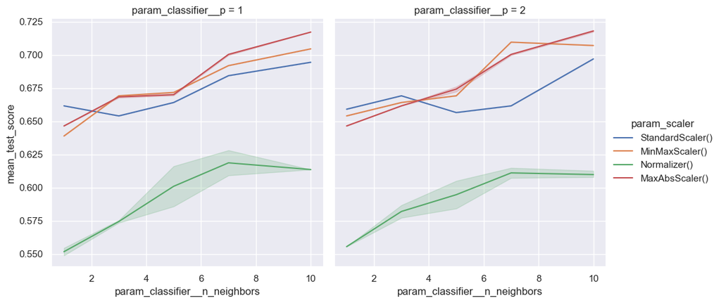

```python
sns.relplot(
      data  = result_df
    , kind  = 'line'
    , x     = 'param_classifier__n_neighbors'
    , y     = 'mean_test_score'
    , hue   = 'param_scaler'
    , col   = 'param_classifier__p'
)

plt.savefig(f'../images/param_classifier__n_neighbors{col}.png')
plt.show()
```

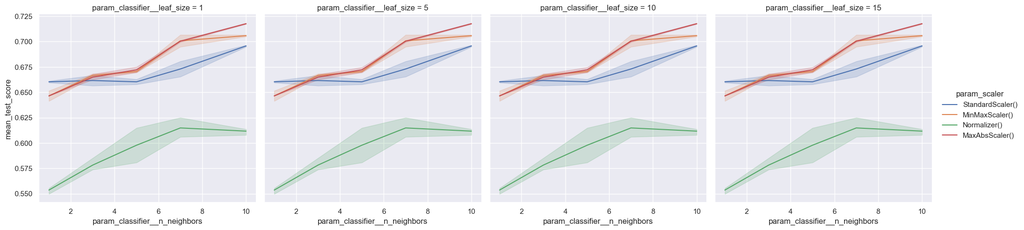

```python
sns.relplot(
      data  = result_df
    , kind  = 'line'
    , x     = 'param_classifier__n_neighbors'
    , y     = 'mean_test_score'
    , hue   = 'param_scaler'
    , col   = 'param_classifier__leaf_size'
)

plt.savefig(f'../images/param_classifier__leaf_size{col}.png')
plt.show()
```

TOP OF PAGE/TOC

## PART 7: Deploy Predictive Model to the Cloud

```python
from pathlib import Path
import pickle

filedir = Path('../data')
filedir.mkdir(parents = True, exist_ok = True)

filepath1 = filedir / 'x.pickle'
filepath2 = filedir / 'y.pickle'
filepath3 = filedir / 'pipeline.pickle'

# SAVE the model:
with filepath1.open('wb') as f:
    pickle.dump(X, f)

with filepath2.open('wb') as f:
    pickle.dump(y, f)

with filepath3.open('wb') as f:
    pickle.dump(best_pipe, f)
```

```python
with filepath.open('rb') as f:
    new_knn_model_loaded = pickle.load(f)
```

TOP OF PAGE/TOC

### TESTING WITH POSTMAN, BASH, OR PYTHON:

#### [AWS EC2: Link to Online Model](http://ec2-35-87-26-229.us-west-2.compute.amazonaws.com:5555/scoring)

> ```
> # Imports required to create a Flask application and API
> from flask import Flask, Request
> from flask_restful import Resource, Api
> import pandas as pd
> import pickle
> from sklearn.model_selection import train_test_split
>
> # Create a flask application:
> app = Flask(__name__)
>
> # Instantiate the API
> # Pass an instance of the flask application
> api = Api(app)
>
> class RawFeatures:
>    def __init__(self, feats):
>        self.feats = feats
>
>    def fit(self, X, y=None):
>        pass
>
>    def transform(self, X, y=None):
>        return X[self.feats]
>
>    def fit_transform(self, X, y=None):
>        self.fit(X)
>        return self.transform(X)
>
> # Now, we will load our model (from pickle)
> x = pickle.load(open("../data/x.pickle", "rb"))
> y = pickle.load(open("../data/y.pickle", "rb"))
> pipeline = pickle.load(open("../data/pipeline.pickle", "rb"))
>
> # Create resource endpoint to communicate the ML model
> class Scoring(Resource):
>    def get(self):
>        X_train, X_test, y_train, y_test = train_test_split(x, y, test_size=1/3, random_state=0)
>        pipeline.fit(X_train, y_train)
>
>        return {
>            "training_score": pipeline.score(X_train, y_train),
>            "test_score": pipeline.score(X_test, y_test)
>        }
>
> # Assign an endpoint to the API:
> api.add_resource(Scoring, '/scoring')
>
> # The last thing to do is to create an application run when the file api.py
> # is run directly (not imported as a module from another script).
> if __name__ == '__main__':
>    app.run(debug=True, host='0.0.0.0', port=5000)
> ```

TOP OF PAGE/TOC